# The Politics of Corruption

Lecture 3: Incentives, Rents, and the Principal–Agent Problem

Bogdan G. Popescu

bgpopescu@tec.mx

Tecnológico de Monterrey

## Four questions for today

```
%%{init: {"fontSize":20,"theme":"base","themeVariables":{"fontSize":"20px","fontFamily":"Arial, Helvetica, sans-serif","primaryColor":"#eef1f4","primaryTextColor":"#1e293b","primaryBorderColor":"#334155","lineColor":"#334155","textColor":"#334155","edgeLabelBackground":"#f9fafb"},"flowchart":{"htmlL…
flowchart LR
  A["1. Why can the<br/>officer ask?"] --> B["2. Why do both<br/>sides go along?"]
  B --> C["3. What are the<br/>warning signs of<br/>corruption risk?"]
  C --> D["4. One bribe<br/>or many?"]
  classDef step fill:#eef1f4,stroke:#334155,stroke-width:2px,color:#1e293b;
  classDef last fill:#e3ece9,stroke:#4a7c6f,stroke-width:3px,color:#1e293b;
  class A,B,C step;
  class D last;
```

## By the end of today

1. Explain how a **monopoly** over a permit turns into a **rent**.
2. Read a bribe as each side’s **best response**, and weigh the gain against the expected cost of being caught.
3. Name the **principal–agent–client** problem behind an official’s discretion.
4. Score an office on **monopoly, discretion and accountability** — and say when discretion is safe.
5. Tell apart corruption **with theft** and **without theft**, and say which one spreads.
6. Say why gatekeepers who must **all** be paid take more, and leave less trade, than a single monopolist.

# I. Why can the officer ask?

## Sofia cannot go anywhere else

- She cannot ask a different officer.
- She cannot bring the goods in somewhere else.
- She cannot wait: her customers will not.
- He controls something she badly needs.

Whenever one person controls the only door, that person has power.

## Why the officer has power

```
%%{init: {"fontSize":20,"theme":"base","themeVariables":{"fontSize":"20px","fontFamily":"Arial, Helvetica, sans-serif","primaryColor":"#eef1f4","primaryTextColor":"#1e293b","primaryBorderColor":"#334155","lineColor":"#334155","textColor":"#334155","edgeLabelBackground":"#f9fafb"},"flowchart":{"htmlL…
flowchart LR
  A["Sofia needs her<br/>shipment released"] --> B["Only this officer<br/>can release it"]
  B --> C["She cannot go<br/>anywhere else"]
  C --> D["The officer<br/>has power"]
  classDef base fill:#eef1f4,stroke:#334155,stroke-width:2px,color:#1e293b;
  classDef prize fill:#f0e6d6,stroke:#b7943a,stroke-width:3px,color:#1e293b;
  class A,B,C base;
  class D prize;
```

## Where does the bribe come from?

Sofia’s shipment at the border (dollars)

| Sofia’s situation | Amount |
| --- | --- |
| The legal customs fee | $100 |
| What a week’s delay would cost her | $500 |
| What the officer asks for | $20 |

- She will happily pay $20 to avoid losing $500.
- That $500 is what the officer is really selling.

## Two words for what we just saw

**Monopoly** — one gatekeeper, and no way around him.

**A rent** — money you earn by controlling a door, not by doing anything useful.

- Rules create doors: permits, licences, inspections.
- Many of those rules are necessary.
- Every one of them still creates a door.

Both terms follow Shleifer & Vishny (1993, pp. 600–601) and Rose-Ackerman (1978, ch. 1).

## So what?

- We now know why the officer **can** ask.
- That is an opportunity, not yet a bribe.
- Somebody still has to say yes.
- So why does Sofia pay, and why does he risk it?

# II. Why do both sides go along?

## Sofia’s choice

**If she refuses**

- The shipment waits a week.
- Her customers buy from someone else.
- She loses about $500.

**If she pays**

- The bribe costs her $20.
- The shipment leaves today.

Paying is wrong. For Sofia on her own, it is also much cheaper.

## Sofia and the officer, side by side

What each side gains or loses, in dollars

|  | **Sofia pays $20** | **Sofia refuses** |
| --- | --- | --- |
| **Officer asks for a bribe** | Sofia −$20 · Officer +$20 | Sofia −$500 · Officer $0 |
| **Officer just does his job** | — | Sofia $0 · Officer $0 |

- Sofia’s best outcome is the bottom row: nobody asks.
- But once he has asked, paying beats refusing.
- They land top-left — the cell neither of them wanted.

Source: Klitgaard (1988, pp. 69–70).

## Why does he ask in the first place?

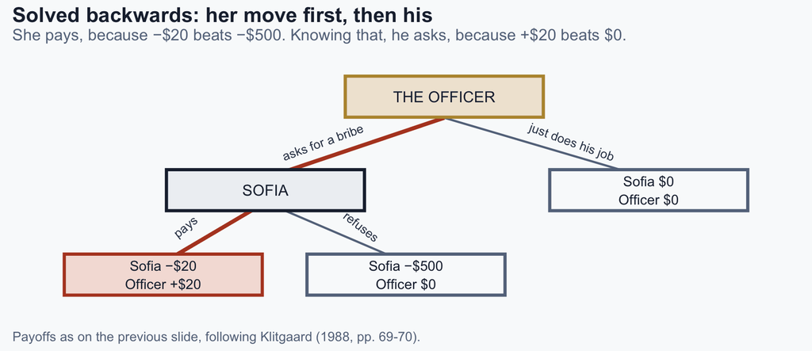

Figure 1

**Best response** — the choice that pays you most, taking the other side’s choice as given. He asks because he can already see what her best response will be.

## Three reasons firms pay

- *“Pay $20 and I will stamp it today.”*
- *“Pay me and I will make sure you win the contract.”*
- *“Pay me and I will forget the tax you owe.”*

Speed money · Buying an advantage · Buying non-enforcement

Categories after Rose-Ackerman (1978, ch. 1) and Shleifer & Vishny (1993, pp. 601, 604).

## The boss cannot see everything

- A minister cannot inspect every shipment herself.
- So she hires officers to do it for her.
- The officer is at the border. She is not.
- He knows what happened. She reads a summary.

The person you trust to do the job may use the job for themselves.

## Boss, official, firm

```
%%{init: {"fontSize":19,"theme":"base","themeVariables":{"fontSize":"19px","fontFamily":"Arial, Helvetica, sans-serif","primaryColor":"#eef1f4","primaryTextColor":"#1e293b","primaryBorderColor":"#334155","lineColor":"#334155","textColor":"#334155","edgeLabelBackground":"#f9fafb"},"flowchart":{"htmlL…
flowchart LR
  P["THE BOSS<br/>the minister<br/>(principal)"]
  A["THE OFFICIAL<br/>the customs officer<br/>(agent)"]
  C["THE FIRM<br/>Sofia<br/>(client)"]
  P -->|"gives the job"| A
  A -->|"serves"| C
  C -.->|"bribe"| A
  A -.->|"reports"| P
  classDef principal fill:#e3ece9,stroke:#4a7c6f,stroke-width:3px,color:#1e293b;
  classDef agent fill:#f0e6d6,stroke:#b7943a,stroke-width:3px,color:#1e293b;
  classDef client fill:#eef1f4,stroke:#334155,stroke-width:2px,color:#1e293b;
  class P principal;
  class A agent;
  class C client;
```

Source: Klitgaard’s principal–agent–client model (1988, pp. 69–73). Dotted arrows are what the boss cannot easily see.

## What he gains, what he might lose

**What the officer gains**

- The bribe: **$20**.

**What the officer might lose**

- Chance of being caught: **1 time in 10**.
- Fine if caught: **$100**.
- So on average the risk costs him **$10**.

$20 gained against $10 expected to be lost. He takes the bribe.

## When is the bribe too risky?

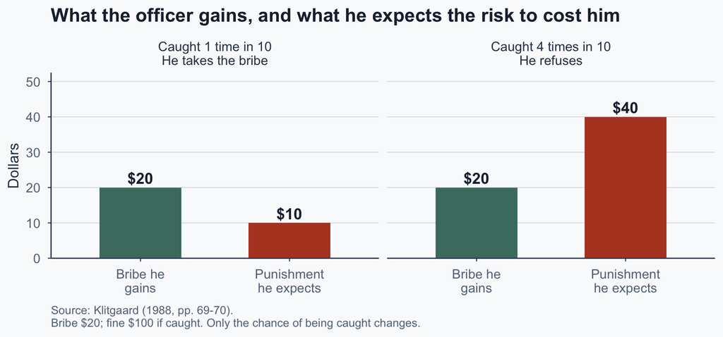

Figure 2: He refuses once the expected punishment — the chance of being caught times the fine — passes the bribe.

## So what?

- Sofia pays because refusing costs her more.
- The officer asks because the risk looks small.
- We need not assume either is unusually wicked.
- Change those numbers and the behaviour changes.

# III. Three warning signs of corruption risk

## Three warning signs of corruption risk

- **No alternative.** Can the citizen go somewhere else?
- **Unclear rules.** Can the official decide almost anything?
- **Nobody checks.** Will anyone find out, and act?

Sofia’s border post scores badly on all three.

## A way to remember them

> **more monopoly + more discretion − less accountability = more corruption risk**
- Robert Klitgaard writes this as **C = M + D − A**.
- It is **not** real mathematics. It is a memory device.
- The terms have no units; you cannot add them up.
- It tells you *where* to look, not *how much* there is.

Klitgaard (1988, box 12, p. 75) calls it “a stylized equation” — his own wording is the warning.

## The three signs at the border

What each warning sign directs you to look for

| Warning sign | The question | At Sofia’s border post |
| --- | --- | --- |
| Monopoly | Can she go elsewhere? | One lane, one officer on duty |
| Discretion | Who decides, and on what basis? | He picks which trucks to open |
| Accountability | Who checks, and what follows? | No records, no rotation, no appeal |

Source: Klitgaard (1988, pp. 74–75, and box 15, p. 88).

## Exercise 1 · Read the office

A city office issues licences for food stalls. One inspector covers the whole market. He decides whether a stall is “clean enough”. He writes the result on a paper form he keeps in his desk.

1. Three warning signs are hiding in that description. Name them.
2. Which of the three is the most dangerous here — and why that one?

5 minutes · one pair reports, the others say where they disagree

## Is letting officials choose always bad?

- “Unclear rules” says an official should not decide freely.
- But you want the bridge built by someone who can build it.
- The cheapest bid is not always the best builder.
- So: does letting officials choose let dirtier firms in?

Decarolis, Fisman, Pinotti & Vannutelli (2025, pp. 214–216). Over 200,000 Italian public works contracts, 2000–2016.

## Discretion is much less dangerous when competition stays strong

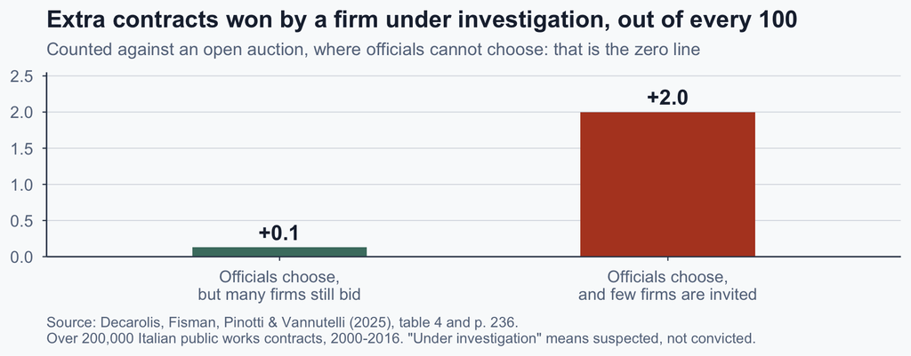

Figure 3: Choice alone: almost no change. Choice with few bidders: two more contracts in every hundred.

In these contracts, letting an official pick the winner mattered little — as long as plenty of firms were still allowed to bid.

## Checking everyone is expensive

- Auditors, inspectors, cameras and courts all cost money.
- Chasing the last small bribe costs more than it saves.
- Klitgaard’s blunt version: the best amount is not zero.
- So aim the effort where the harm is greatest.

Source: Klitgaard (1988, ch. 2, pp. 24–27). He means this as a budgeting point, not as an excuse.

## So what?

- Three warning signs let you inspect any office.
- Letting officials choose is not the danger by itself.
- Choice with no competition is the danger.
- Now: what if Sofia faces more than one officer?

# IV. One bribe or many?

## Bribery when the state still gets paid

He records the shipment and charges the $100, exactly as the rules say. He cannot waive that fee — but he does decide *when* the goods move. The $20 buys today instead of next week.

Sofia pays the legal fee, and a bribe on top (dollars)

| Who | Amount |
| --- | --- |
| Sofia pays in total | $120 |
| The government receives | $100 |
| The officer keeps | $20 |

- Sofia is $20 worse off than if the rules were followed.
- She has a reason to complain.

## Bribery when the state gets nothing

This time he never writes the shipment down. No record, so no $100 fee is ever owed. He waves the truck through and keeps $60 for himself.

The officer writes nothing down and keeps the lot (dollars)

| Who | Amount |
| --- | --- |
| Sofia pays in total | $60 |
| The government receives | $0 |
| The officer keeps | $60 |

- Sofia pays $60 instead of $100. She is **better** off.
- Now nobody in the room wants to complain.

## Where the money goes

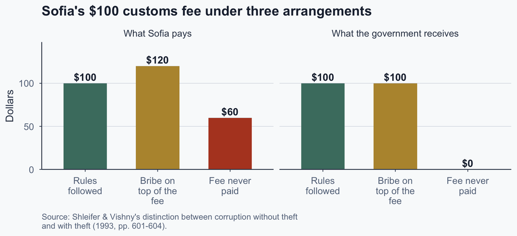

Figure 4: When the fee is skipped, the loser is the treasury — and it is absent.

## Why almost nobody reports it

- When the fee is skipped, Sofia saves money too.
- An honest importer who pays $100 is undercut.
- To survive, she must find her own friendly officer.
- Both sides now want the same thing: silence.

When the state is robbed, both sides come out ahead — so both sides want silence.

Source: Shleifer & Vishny (1993, p. 604). Their fix: first make theft from the state visible in the accounts.

## Sixty tolls on the Rhine

A merchant sails down the river. Sixty different rulers each stop him and demand a toll.

- What happens to the final price?
- Who stops making the journey at all?

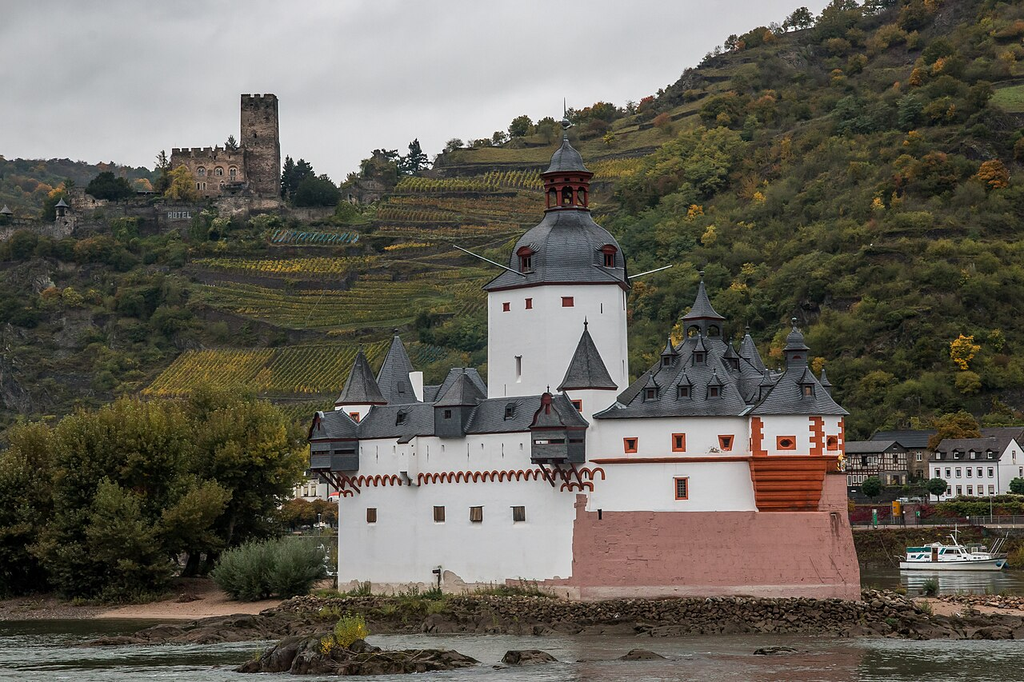

Pfalzgrafenstein, a toll station built in the middle of the Rhine at Kaub (from 1326). Photo © Gary Bembridge, [CC BY 2.0](https://creativecommons.org/licenses/by/2.0/), via Wikimedia Commons.

Around 1400 the Rhine carried some 60 independent tolls; English rivers carried none. Reported in Shleifer & Vishny (1993, p. 608), citing Heilbroner (1962).

## Three ways to arrange the offices

```
%%{init: {"fontSize":20,"theme":"base","themeVariables":{"fontSize":"20px","fontFamily":"Arial, Helvetica, sans-serif","primaryColor":"#eef1f4","primaryTextColor":"#1e293b","primaryBorderColor":"#334155","lineColor":"#334155","textColor":"#334155","edgeLabelBackground":"#f9fafb"},"flowchart":{"htmlL…
flowchart LR
  A1["EITHER WILL DO<br/>two offices,<br/>either can approve"] --> A2["Bribe near zero<br/>Most trade happens"]
  B1["ONE OFFICE<br/>one office approves<br/>everything at once"] --> B2["One medium bribe<br/>Some trade happens"]
  C1["ALL MUST AGREE<br/>five offices,<br/>each can stop her"] --> C2["Bribe after bribe<br/>Least trade happens"]
  classDef good fill:#e3ece9,stroke:#4a7c6f,stroke-width:3px,color:#1e293b;
  classDef mid fill:#f0e6d6,stroke:#b7943a,stroke-width:3px,color:#1e293b;
  classDef bad fill:#f4e0da,stroke:#b44527,stroke-width:3px,color:#1e293b;
  class A1,A2 good;
  class B1,B2 mid;
  class C1,C2 bad;
```

Source: Shleifer & Vishny (1993, sec. III, pp. 604–608). The Rhine tolls are the third case.

## When every office can say no

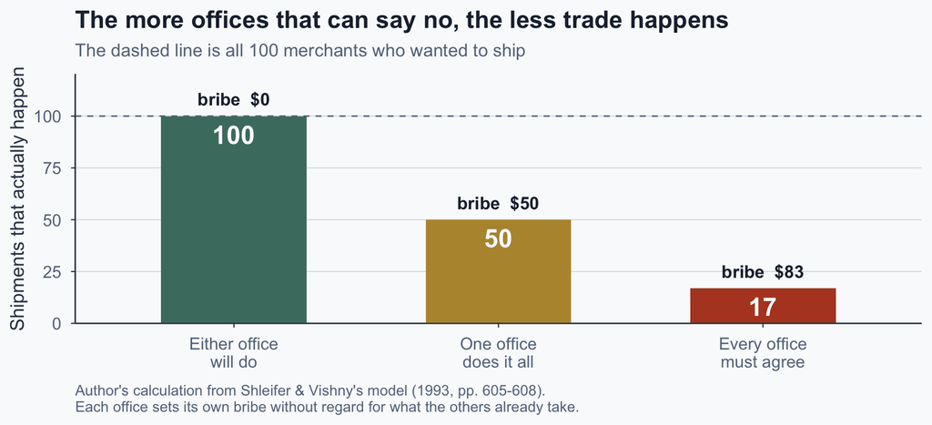

Figure 5: Each office adds its own demand, so the merchant pays more and fewer shipments are worth making.

## Exercise 2 · One river

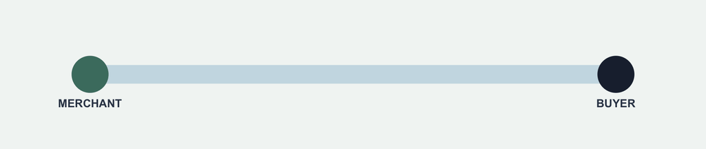

Figure 6

One merchant, one river. Her cargo is worth a number between **$1 and $100** — it is on my card, and you do not get to see it.

She finds out what the tolls add up to **before** she sets out. So it is the whole trip or none of it.

Tolls **under** the card → she sails → every toll gets paid  
Tolls **over** the card → she turns back → **nobody gets paid**

## First: just one toll station

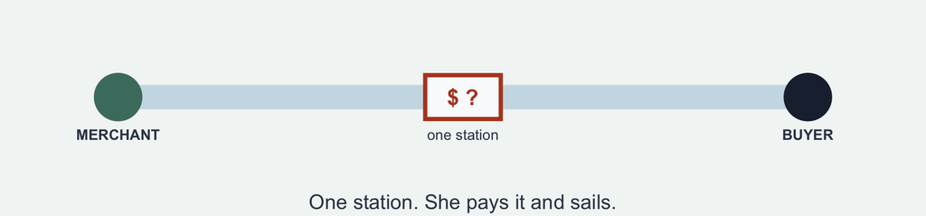

Figure 7

**What should it charge?**

Too much and she turns back with nothing paid. Too little and you left money on the table. The best answer is about **$50** — she sails roughly half the time.

## Now a toll for every team

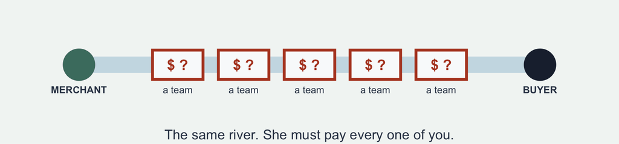

Figure 8

**Same river. Same merchant. One thing has changed:** now she has to get past all of you.

Your team is one station. **Write your toll. Do not show it. Do not talk to the other teams.**

We reveal together and add them up. **We play this twice.**

## Scenario 1 · The ship passes

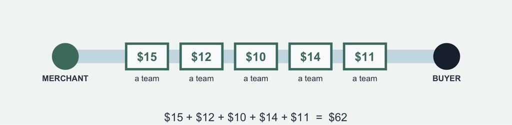

Figure 9

The card said **$72**. The tolls came to **$62**.

She sails — and every team is paid.

## Scenario 2 · The ship turns back

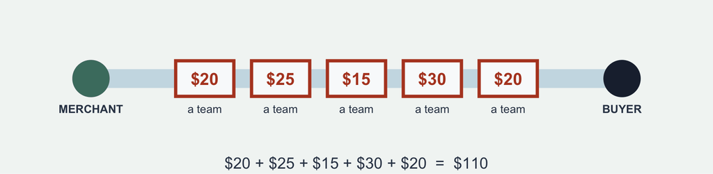

Figure 10

The card said **$72**. The tolls came to **$110**.

She turns back — and nobody is paid. Not one team.

## So what?

- Splitting corruption between many hands makes it worse.
- The many offices even collect less in total.
- A second office issuing the same permit cuts monopoly power.
- Elections and a free press work on accountability instead.

Source: Shleifer & Vishny (1993, pp. 605–611). Note their uncomfortable warning about decentralisation reforms.

## Five questions to ask about any office

1. **Monopoly** — what does the official control, and can the citizen go elsewhere?
2. **Discretion** — who decides, and against what written rule?
3. **Accountability** — who can find out, and who can punish?
4. **Theft** — does the state still get paid, or does the fee disappear?
5. **Many hands** — how many officials can block the same transaction?

Corruption is not only about bad people. It is about **institutional design**.

## References

Decarolis, F., Fisman, R., Pinotti, P., & Vannutelli, S. (2025). Rules, discretion, and corruption in procurement: Evidence from Italian government contracting. *Journal of Political Economy Microeconomics, 3*(2), 213–254. https://doi.org/10.1086/732654

Heilbroner, R. L. (1962). *The making of economic society*. Prentice-Hall.

Klitgaard, R. (1988). *Controlling corruption*. University of California Press.

## References (continued)

Rose-Ackerman, S. (1978). *Corruption: A study in political economy*. Academic Press.

Shleifer, A., & Vishny, R. W. (1993). Corruption. *The Quarterly Journal of Economics, 108*(3), 599–617. https://doi.org/10.2307/2118402